# Comparing common and rare single variant and gene aggregate instrumentation strategies for MR

Author

Aimee Hanson

Published

April 9, 2025

## Introduction

Classically, Mendelian Randomisation (MR) methods utilising trait-associated genetic variants from GWAS studies have employed common polymorphisms (population MAF > 1%) targeted by genotyping chips, or reliably imputed from reference populations, to instrument modifiable exposures. However, common variants tested in GWAS typically explain a very small fraction of the variability in a measured complex trait, potentially exhibit pleiotropic effects acted upon by balancing selection, and are rarely causal. Rare variants, which typically show large biological effects (e.g. through abolishing protein expression) provide a means of more unambiguously instrumenting relevant molecular processes. Comparison of causal estimates derived using differing methods of genetically instrumenting modifiable exposures may enhance the interpretation of the biological mechanisms underlying exposure-outcome relationships. This includes using variants from across the allele frequency spectrum, but also leveraging rare variant aggregate approaches to instrument gene-level perturbations in expression and function.

Causal estimates for pairwise combinations of the exposure and outcome relationships below have been derived using twelve instrumentation strategies.

**Exposures:** Low density lipoprotein levels (LDL direct), Body Mass Index (BMI), Vitamin D, Triglycerides, Glycated Haemoglobin (HbA1c), Mean Platelet Volume (MPV), IGF-1, Waist-to-Hip Ratio (BMI-corrected), Red Blood Cell (RBC) erythrocyte count and Mean Corpuscular Volume (MCV)

**Outcomes:** Coronary Artery Disease (CAD), Type 2 Diabetes (T2D), Multiple Sclerosis (MS), Ischemic Stroke, Atrial Fibrillation (AF), Venous Thromboembolism (VTE), Prostate Cancer and Hypertension.

### Instruments

Twelve sets of instruments for each exposure have been extracted from across three sources (DeepRVAT gene impairment scores, Genebass whole exome single variants and aggregate burden masks and UKB common variant GWAS summary statistics):

**Common GWAS**  
Associated common variants from UKB GWAS (>1% MAF)

**Genebass (variants)**  
Common exome-wide (>5% MAF, LD clumped)  
Low-frequency exome-wide (1-5% MAF, LD clumped)  
Rare exome-wide (0-1% MAF, both unfiltered and filtered to the top hit per gene)  
Ultra-rare exome-wide (0-0.1% MAF, both unfiltered and filtered to the top hit per gene)

**Genebass (masks)**  
pLOF burden mask  
missense/low-confidence burden mask  
pLOF/missense/low-confidence burden mask  
synonymous burden mask

**DeepRVAT (impairment scores)**  
gene impairment score (<0.1% MAF)

Here the focus is on 10 of the tested exposure-outcome pairs where differing instrumentation strategies show heterogeneity in causal effect estimates.

## Data import

Read in MR results from `scripts/02_analysis_complextraits/001_performMR.R` and harmonised summary statistics:

```r
# Import MR results
load(file = file.path(res_dir, "results_complextrait_MR.rda"))
# Import harmonised study data
load(file = file.path(data_dir, "harmonised", "harmonised_studies.rda"))

# Retain exposure-outcome pairs with significant IVW estimate for at least one instrumentation strategy
res_MR <- lapply(results_MR, function(x){
  sig_ivw <- x |> filter(method == "Inverse variance weighted" & pval < 0.05)
  if(nrow(sig_ivw) == 0){
    return(NULL)
  } else {
    return(x)
  }
})

keep_pairs <- names(unlist(lapply(res_MR, nrow)))
# Remove BMI exposure pairs (low instrument numbers)
keep_pairs <- keep_pairs[!(grepl("^BMI",keep_pairs))] # 44 exposure-outcome pairs

# Top interesting
keep_top <- c(
  "HbA1c_CHD", "HbA1c_T2D", "LDL_CHD", "LDL_MS", "LDL_T2D", "Trig_CHD",
  "Trig_T2D", "WHRadjBMI_CHD", "WHRadjBMI_Hypertension", "WHRadjBMI_T2D")

res_MR <- res_MR[keep_top]

# Annotations for study sets
instrument_type <- c("genescore",rep("mask",4), rep("variant",7))
names(instrument_type) <- names(harmonised_studies[[1]])

instrument_class <- c("genescore",
                      "mask:missense|LC","mask:pLOF","mask:pLOF|missense|LC","mask:synonymous",
                      "exome:common","exome:lowfreq","exome:rare","exome:ultrarare",
                      "exome:rare (top)","exome:ultrarare (top)","genome:common")

names(instrument_class) <- names(harmonised_studies[[1]])
```

```r
# Populate missing MAFs from other paired studies if possible

all_mafs <- list()

for(i in 1:length(harmonised_studies)){
  snp_mafs <- do.call("rbind",lapply(harmonised_studies[[i]][names(instrument_type[instrument_type=="variant"])], function(x){
    x[,c("SNP","effect_allele.exposure","eaf.exposure")]
  })) |> unique()
  all_mafs[[i]] <- snp_mafs
}

all_mafs <- do.call("rbind",all_mafs) |> arrange(SNP) |> filter(!is.na(eaf.exposure), duplicated(SNP) == FALSE)

for(i in 1:length(harmonised_studies)){
  for(j in 1:length(harmonised_studies[[i]])){

    snp_id <- harmonised_studies[[i]][[j]]$SNP
    if (all(is.na(harmonised_studies[[i]][[j]]$eaf.exposure))){
      harmonised_studies[[i]][[j]]$eaf.exposure <- all_mafs[match(snp_id, all_mafs$SNP),"eaf.exposure"]
    }
    if (all(is.na(harmonised_studies[[i]][[j]]$eaf.outcome))){
      harmonised_studies[[i]][[j]]$eaf.outcome <- all_mafs[match(snp_id, all_mafs$SNP),"eaf.exposure"]
    }
  }
}

harmonised_studies <- harmonised_studies[keep_top]
```

### Check instrument selection

Single variant instruments only:

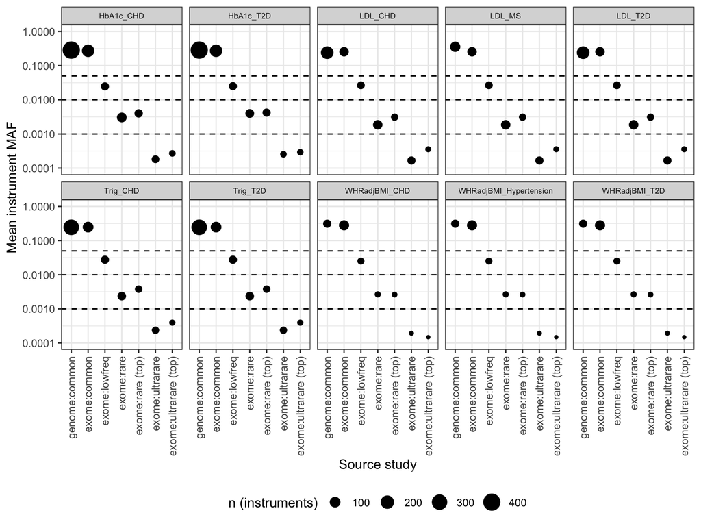

```r
# Check number of instruments, minor allele frequency and average beta values across instrument sets
instrument_MAFs <- list()

for(i in 1:length(harmonised_studies)){
  MAFs <- do.call("rbind", lapply(harmonised_studies[[i]], function(x){
    x |>
      mutate(maf = ifelse(eaf.exposure > 0.5, 1-eaf.exposure, eaf.exposure)) |>
      group_by(exposure,outcome) |>
      dplyr::summarise(
        n_instruments = n(),
        mean_maf = mean(na.exclude(maf)),
        mean_beta = mean(abs(beta.exposure)))
  }))
  MAFs$pairs <- names(harmonised_studies)[i]
  MAFs$study <- names(harmonised_studies[[i]])
  MAFs$instrument_type <- instrument_type[MAFs$study]
  MAFs$instrument_class <- instrument_class[MAFs$study]

  instrument_MAFs <- c(instrument_MAFs, list(MAFs))
}

instrument_MAFs <- do.call("rbind", instrument_MAFs) |>
  mutate(instrument_class = factor(instrument_class, levels = c(
    "genome:common",
    "exome:common","exome:lowfreq",
    "exome:rare","exome:rare (top)",
    "exome:ultrarare","exome:ultrarare (top)",
    "mask:synonymous","mask:missense|LC",
    "mask:pLOF|missense|LC","mask:pLOF",
    "genescore")))

## Plot average instrument MAF

p_MAF <- ggplot(instrument_MAFs |> filter(instrument_type == "variant"),
       aes(x = instrument_class, y = mean_maf, size = n_instruments)) +
  geom_point() +
  facet_wrap(.~pairs, nrow = 2) +
  geom_hline(yintercept = 0.01, lty = 2) +
  geom_hline(yintercept = 0.05, lty = 2) +
  geom_hline(yintercept = 0.001, lty = 2) +
  scale_y_log10(labels = scales::comma, limits = c(0.0001,1)) +
  theme_bw() +
  theme(legend.position = "bottom",
        axis.text.x = element_text(angle = 90, hjust = 1, vjust = 0.5),
        strip.text = element_text(size = 6.5)) +
  labs(y = "Mean instrument MAF", x = "Source study",
       size = "n (instruments)")

p_MAF
```

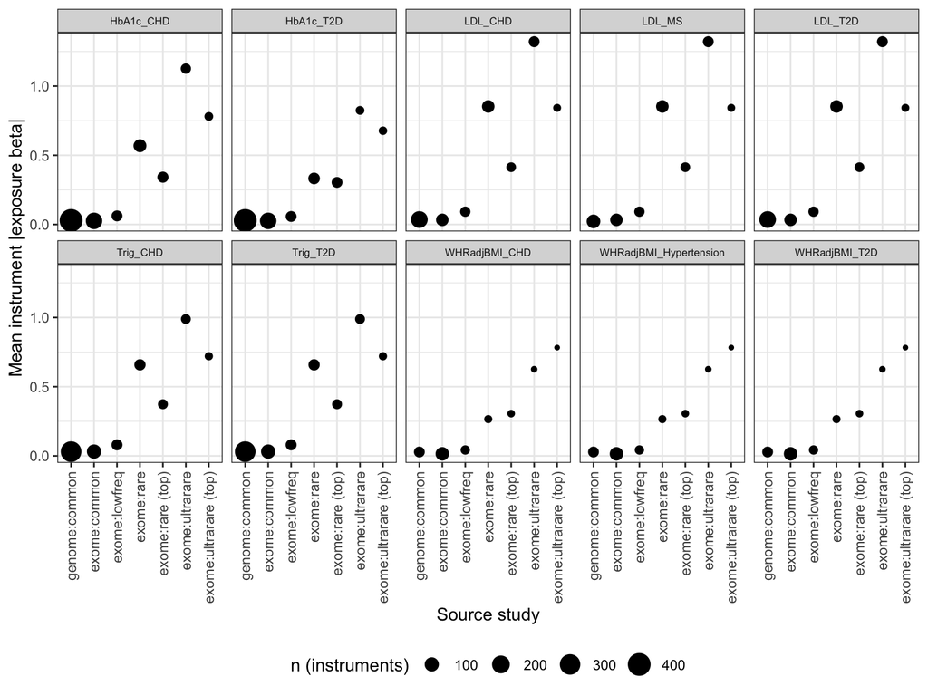

```r
## Plot average instrument beta

p_beta <- ggplot(instrument_MAFs |> filter(instrument_type == "variant"),
       aes(x = instrument_class, y = mean_beta, size = n_instruments)) +
  geom_point() +
  facet_wrap(.~pairs, nrow = 2) +
  theme_bw() +
  theme(legend.position = "bottom",
        axis.text.x = element_text(angle = 90, hjust = 1, vjust = 0.5),
        strip.text = element_text(size = 6.5)) +
  labs(y = "Mean instrument |exposure beta|", x = "Source study",
       size = "n (instruments)")

p_beta
```

## Mendelian randomisation

### IVW estimates across instrument sets

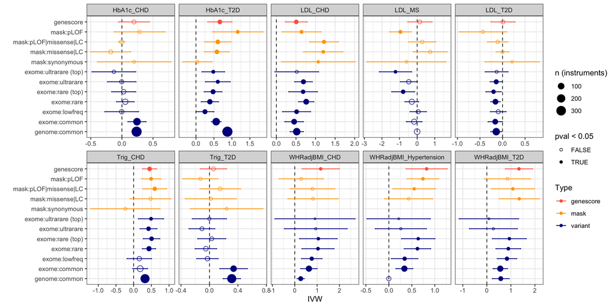

```r
res_IVW <- do.call("rbind", res_MR) |> filter(method == "Inverse variance weighted") |>
  mutate(instrument_type = instrument_type[study],
         instrument_class = factor(instrument_class[study],
                                   levels = c(
                                     "genome:common",
                                     "exome:common","exome:lowfreq",
                                     "exome:rare","exome:rare (top)",
                                     "exome:ultrarare","exome:ultrarare (top)",
                                     "mask:synonymous","mask:missense|LC",
                                     "mask:pLOF|missense|LC","mask:pLOF",
                                     "genescore")))

ggplot(res_IVW, aes(x = b, y = instrument_class, colour = instrument_type)) +
  facet_wrap(.~pair, nrow = 2, scale = "free_x") +
  geom_vline(xintercept = 0, colour = "grey20", lty = 2) +
  geom_point(aes(pch = pval<0.05, size = nsnp)) +
  geom_errorbar(aes(xmin = b-1.96*se, xmax = b+1.96*se), width = 0.1) +
  scale_colour_manual(values = c("tomato","orange","darkblue")) +
  scale_shape_manual(values = c(1,19)) +
  theme_bw() +
  labs(size = "n (instruments)", colour = "Type", x = "IVW", y = "")
```

### MR Egger intercept (horizontal pleiotropy)

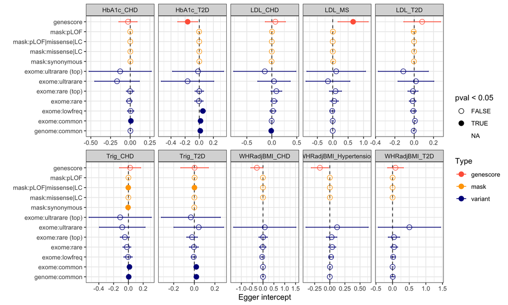

```r
# Perform MR on each exposure-outcome pair, across each of 12 instrument sets
res_egger <- list()

for(i in 1:length(harmonised_studies)){
  res_list <- list()

  for(j in 1:length(harmonised_studies[[i]])){
    dat <- harmonised_studies[[i]][j]

    if(nrow(dat[[1]]) == 1){
      res <- data.frame(
        id.exposure = NA,
        id.outcome = NA,
        outcome = NA,
        exposure = NA,
        egger_intercept = NA,
        se = NA,
        pval = NA
      )
    } else {
      res <- TwoSampleMR::mr_pleiotropy_test(dat[[1]])
    }

    res$pair <- names(harmonised_studies)[i]
    res$study <- names(harmonised_studies[[i]])[j]

    res_list <- c(res_list, list(res))
  }
  res_join <- do.call("rbind", res_list)
  res_egger <- c(res_egger, list(res_join))
}

res_egger <- do.call("rbind", res_egger) |>
  mutate(instrument_type = instrument_type[study],
         instrument_class = factor(instrument_class[study],
                                   levels = c(
                                     "genome:common",
                                     "exome:common","exome:lowfreq",
                                     "exome:rare","exome:rare (top)",
                                     "exome:ultrarare","exome:ultrarare (top)",
                                     "mask:synonymous","mask:missense|LC",
                                     "mask:pLOF|missense|LC","mask:pLOF",
                                     "genescore")))

ggplot(res_egger, aes(x = egger_intercept, y = instrument_class, colour = instrument_type)) +
  facet_wrap(.~pair, nrow = 2, scale = "free_x") +
  geom_vline(xintercept = 0, colour = "grey20", lty = 2) +
  geom_point(aes(pch = pval<0.05), size = 3) +
  geom_errorbar(aes(xmin = egger_intercept-1.96*se, xmax = egger_intercept+1.96*se), width = 0.1) +
  scale_colour_manual(values = c("tomato","orange","darkblue")) +
  scale_shape_manual(values = c(1,19)) +
  theme_bw() +
  labs(x = "Egger intercept", colour = "Type", x = "IVW", y = "")
```